# CadenaCritica 10

3 tareas en turnos de 4 días; cambio de tarea de 1 día

# Enunciado

Un técnico de la oficina técnica tiene asignadas 3 tareas, cada una de un proyecto distinto, con las duraciones (días de trabajo efectivo) del cuadro. Los 3 jefes de proyecto le presionan para que «avance un poco en lo de todos».

1. Si hace las tareas una detrás de otra en el orden del cuadro, sin interrupciones, ¿qué día termina cada una? ¿Cuál es el tiempo medio de terminación?

2. Si reparte su tiempo en turnos de 4 días, rotando entre las tareas pendientes en el orden del cuadro (multitarea), y cambiar de tarea no le cuesta nada, ¿qué día termina cada una? ¿Cuánto se retrasa cada tarea y cuánto el tiempo medio respecto al apartado 1?

3. Repita los dos cálculos suponiendo que cada vez que pasa de una tarea a otra pierde 1 día en retomarla (preparación, recuperar el hilo). ¿Cuándo termina el último trabajo en cada caso?

4. ¿En qué orden habría que hacerlas, sin multitarea, para minimizar el tiempo medio de terminación? ¿Qué recomienda el método de la cadena crítica sobre la multitarea y por qué?

Tabla 1: Tareas y duraciones (días)

| tarea | duration |
| --- | --- |
| T1 | 11 |
| T2 | 5 |
| T3 | 12 |

# Resolución

## Apartado 1

1. Si hace las tareas una detrás de otra en el orden del cuadro, sin interrupciones, ¿qué día termina cada una? ¿Cuál es el tiempo medio de terminación?

Sin multitarea cada tarea termina cuando han terminado ella y todas las anteriores: los fines son las sumas acumuladas de las duraciones.

Tabla 2: Sin multitarea: día de terminación de cada tarea

|  | T1 | T2 | T3 |
| --- | --- | --- | --- |
| fin = suma acumulada | 11 = 11 | 11 + 5 = 16 | 11 + 5 + 12 = 28 |

Tiempo medio de terminación sin multitarea: (11 + 16 + 28)/3 = **18.33 días**; el último trabajo termina el día 28.

## Apartado 2

2. Si reparte su tiempo en turnos de 4 días, rotando entre las tareas pendientes en el orden del cuadro (multitarea), y cambiar de tarea no le cuesta nada, ¿qué día termina cada una? ¿Cuánto se retrasa cada tarea y cuánto el tiempo medio respecto al apartado 1?

Con multitarea se trabaja 4 días en cada tarea pendiente, por turno, en el orden del cuadro; una tarea sale de la rotación cuando termina. La tabla de turnos recoge cada tramo de trabajo.

Tabla 3: Turnos con multitarea (sin pérdida al cambiar)

|  | 0 | 1 | 2 | 3 | 4 | 5 | 6 | 7 |
| --- | --- | --- | --- | --- | --- | --- | --- | --- |
| tarea | T1 | T2 | T3 | T1 | T2 | T3 | T1 | T3 |
| inicio | 0 | 4 | 8 | 12 | 16 | 17 | 21 | 24 |
| días | 4 | 4 | 4 | 4 | 1 | 4 | 3 | 4 |
| fin | 4 | 8 | 12 | 16 | 17 | 21 | 24 | 28 |

Tabla 4: Día de terminación con y sin multitarea

|  | sin multitarea | con multitarea | retraso |
| --- | --- | --- | --- |
| T1 | 11 | 24 | 13 |
| T2 | 16 | 17 | 1 |
| T3 | 28 | 28 | 0 |
| media | 18.33 | 23 | 4.67 |

El último trabajo termina igual (día 28: el trabajo total es el mismo), pero T1, T2 terminan más tarde: el tiempo medio pasa de 18.33 a 23.00 días (+4.67). Cada proyecto recibe su resultado más tarde y, si la tarea es crítica, el proyecto entero se retrasa.

## Apartado 3

3. Repita los dos cálculos suponiendo que cada vez que pasa de una tarea a otra pierde 1 día en retomarla (preparación, recuperar el hilo). ¿Cuándo termina el último trabajo en cada caso?

Tabla 5: Con pérdida en cada cambio de tarea

|  | sin multitarea | con multitarea |
| --- | --- | --- |
| T1 | 11 | 30 |
| T2 | 17 | 21 |
| T3 | 30 | 35 |
| media | 19.33 | 28.67 |
| cambios de tarea | 2 | 7 |
| días perdidos | 2 | 7 |

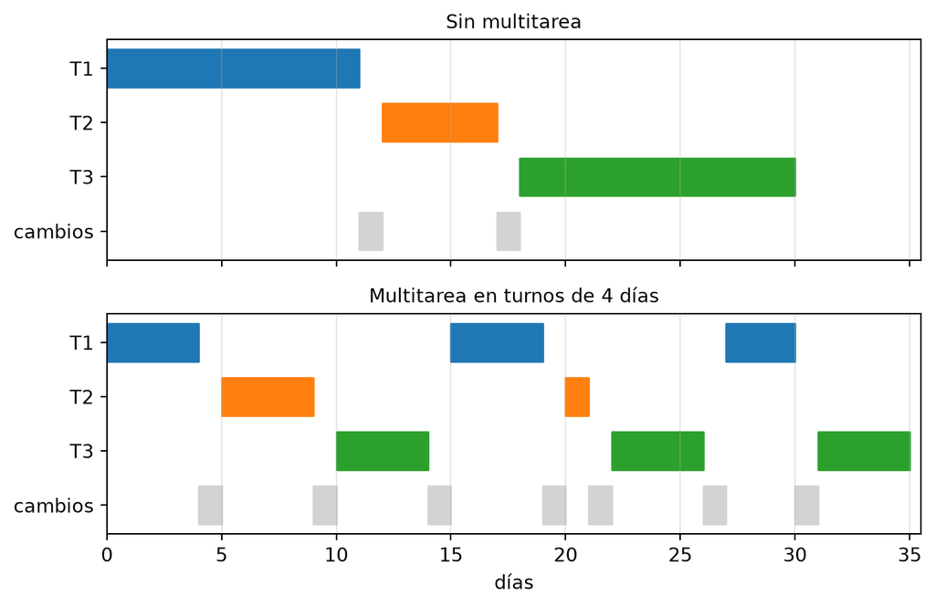

Figura 1: Turnos de trabajo: sin multitarea y con multitarea (con pérdida en cada cambio)

Con la pérdida por cambio, la multitarea ya no sólo retrasa las tareas intermedias: el último trabajo pasa del día 30 al 35 (7 cambios frente a 2), es decir, la persona produce menos. Es el efecto que Goldratt atribuye a la multitarea mal entendida.

## Apartado 4

4. ¿En qué orden habría que hacerlas, sin multitarea, para minimizar el tiempo medio de terminación? ¿Qué recomienda el método de la cadena crítica sobre la multitarea y por qué?

Ordenando de la más corta a la más larga (T2 → T1 → T3) el tiempo medio de terminación es 16.33 días, el mínimo posible sin multitarea (frente a 18.33 en el orden del cuadro): es la regla de la duración más corta primero: si dos tareas seguidas están en orden larga–corta, intercambiarlas adelanta la corta lo que dura la larga y retrasa la larga sólo lo que dura la corta.

El método de la cadena crítica pide **evitar la multitarea** en las actividades de la cadena: quien trabaja en una actividad crítica se dedica a ella hasta terminarla y la entrega en cuanto acaba, como el corredor de relevos. La multitarea alarga todas las actividades que se reparten (cada una termina cuando termina su último turno), retrasa la entrega a las sucesoras y, con la pérdida de cada cambio, reduce la capacidad real del recurso. Para decidir qué tarea va primero, la prioridad la marca el estado de los colchones de cada proyecto, no quien más presiona.

## Autoevaluación

Preguntas de respuesta múltiple con los datos de este ejercicio (la correcta, marcada con ✅, es la primera de cada lista). La celda las exporta también en formato GIFT, con las opciones barajadas, a `~/temp/cuestionario_cadena_critica.gift`, para importarlas en Moodle.

**1. Sin multitarea y en el orden del cuadro, ¿cuál es el tiempo medio de terminación de las tareas?**

- ✅ 18,33 días

- ◻️ 23,00 días

- ◻️ 9,33 días

- ◻️ 28,00 días

*Las tareas terminan en las sumas acumuladas de las duraciones (11, 16, 28); su media es 18,33 días.*

**2. Con multitarea en turnos de 4 días y sin pérdida al cambiar de tarea, ¿qué día termina la última tarea?**

- ✅ día 28

- ◻️ día 32

- ◻️ día 35

- ◻️ día 36

*El trabajo total es el mismo, así que la última tarea termina el mismo día que sin multitarea; lo que se retrasa son las demás.*

**3. Con multitarea en turnos de 4 días y una pérdida de 1 día(s) en cada cambio de tarea, ¿qué día termina la última tarea?**

- ✅ día 35

- ◻️ día 28

- ◻️ día 30

- ◻️ día 39

*Hay 7 cambios de tarea, que añaden 7 días al trabajo: la persona produce menos.*

**4. ¿Qué orden minimiza, sin multitarea, el tiempo medio de terminación?**

- ✅ de la tarea más corta a la más larga

- ◻️ de la tarea más larga a la más corta

- ◻️ el orden en que se asignaron las tareas

- ◻️ repartir el tiempo en turnos iguales

*Es la regla de la duración más corta primero: adelantar una tarea corta retrasa a la larga menos de lo que adelanta a la corta.*